# Ecological Processes

## Operating Models

There are many alternative ways to condition Operating Models which we use to represent resource dynamics

One way is to use an Integrated Stock Assessment like SS or Multifan-CL.

- This implies that the assessment is able to describe nature almost perfectly
- If this is true why bother with MSE?

## Stock Assessments Models

Basing an OM on the current assessment model has arguably the lowest demands for knowledge and data and allows the tRFMOs to make a phased transition from the stock assessment paradigm to a risk based approach.

If a management procedure can not perform well when reality is as simple as implied by an assessment model it is unlikely to perform adequately for more realistic representations of uncertainty about resource dynamics.

## Feedback Control

Feedback is an important element of control systems, i.e. to ensure that monitored signals and inputs do not exceed pre-specified levels.

The ability to control a system depends on uncertainty about the system and measurement errors.

Control systems can be

- **white box** where one has full knowledge of a system, e.g, traditional stock assessment
- **grey box** where a biomass dynamics model with a production function based on only a few parameters is used; or a
- **black box** where the control is based on data alone, e.g. an empirical harvest control rule

## Ecology

## Recruitment dynamics

Many recent studies have shown that parental biomass is a poor predictor of recruitment

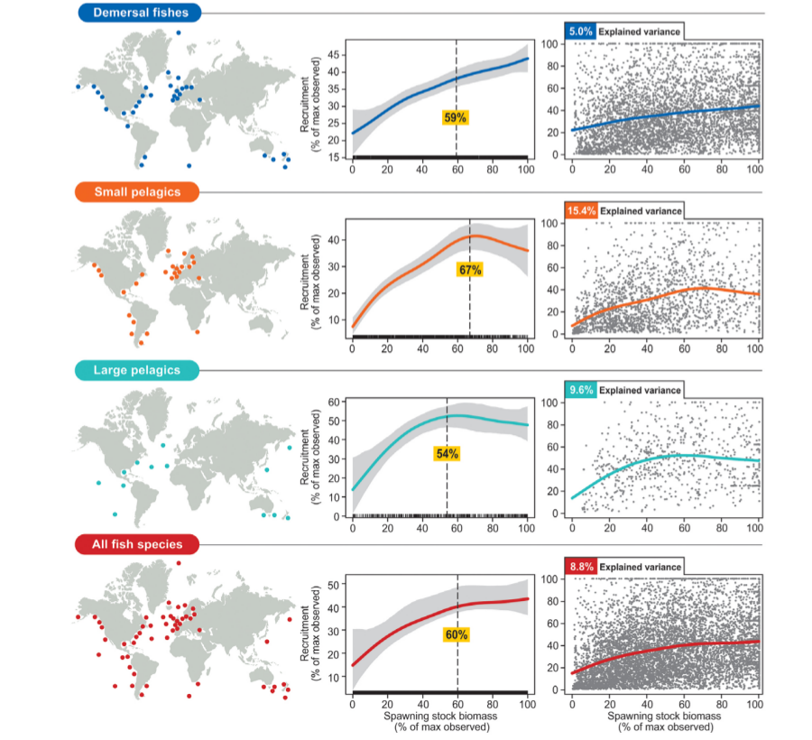

## Recruitment dynamics

Confirmation of Hjort’s assumption that recruitment is mostly a stochastic process not primarily driven by parental stock size

Recruitment is a multi-variate process in which timing and localisation are crucial where high recruitment generally happens because favorable biotic and abiotic conditions were synchronous at the good place i.e.

- Cushing match/mis-match hypothesis.

## Density Dependence

There are many important processes that are not modelled in stock assessments and affect the robustness of control systems, and the response of system to perturbation. Density dependence (DD) may occur many in and interact with many processes e.g.

- Delayed DD of a year-class on a younger one
- Mediatiation by environmental change
- …

## Ecological processes

To ensure a control system is robust requires OMs to be conditioned on ecological processes that affect the behaviour of management systems; i.e.

- The focus is on the future, not on fitting historical data as when conditioning an OM on a stock assessment.
- This is a less data, and more hypothesis-orientated approach.

## Bluefin Example

The nature of the biological processes is fundamental for management

- Fromentin and Kell (2007) showed that if the long-term fluctuations in BFT arise from changes in carrying capacity, the current assessment models were able to track the stock but failed if the fluctuations arise from changes in migration.
- The most robust management strategy was a size limit.

## Time series

Recruitment estimates, White noise?

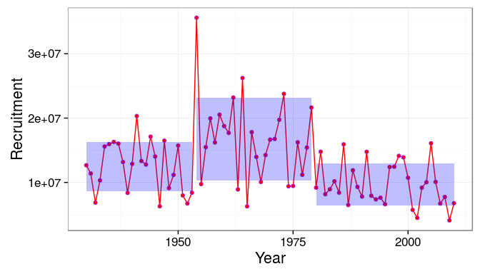

## Ecology

Production estimates, Red noise?

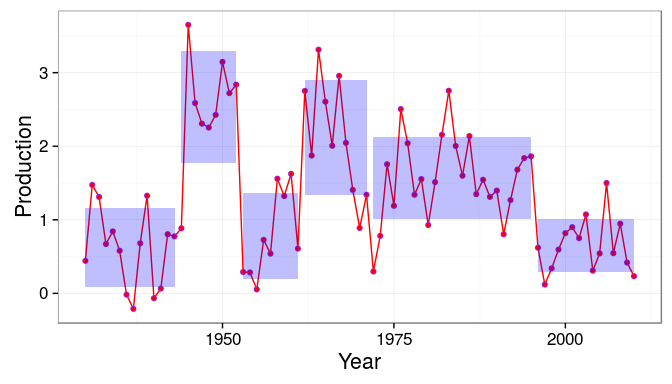

## Proposal for the Folio

## Control Theory Paper

Control Theory has been used since dawn of time e.g. the self-regulation of windmills, the governor on steam engines etc.

Feedback control is an important part of biological systems, e.g.

- Evolution
- Metabolic and gene-regulatory networks

Most theoretical work has been developed for electro-mechanical systems which are easily linearisable around equilibrium, measureable, there is freedom in designing controllers, and of implementing control, …

Use the MSE framework to explore the application of the principals of systems control theory: e.g. feedback, information, measurement, error, etc.

## Natural Systems

Natural resource systems, particularly wild fisheries, have almost none of these characteristics as they are

- Noisy systems that are not at equilibrium
- Have infrequent measurement
- Limited range of available management techniques
- High implementation error

## Objective

What, if anything, can we take from systems control theory that is useful for us?

- System identification - understanding of underlying stability and dynamics of system
- Tuning of HCRs (i.e. tuning of controllers)
- Alternative things to measure, e.g. not just state, but rate of change of state
- What else?